# Dateiformate

### Datei

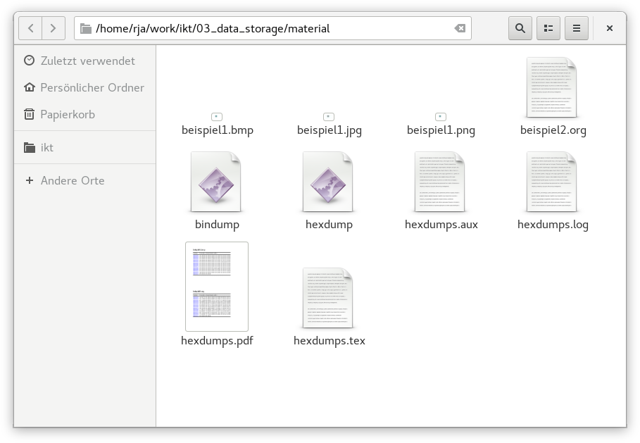

### Dateiformat

[figure not shown]

#### binär vs. "plain text"

[figure not shown]

#### proprietär vs. frei & offen vs. nicht öffentlich

[figure not shown]

Siehe [WP: Open format](https://en.wikipedia.org/wiki/Open_format) und [WP: Proprietary format](https://en.wikipedia.org/wiki/Proprietary_format).

#### Spezifisch vs. Container

##### Spezifisch

- Festlegung auf eine Art von Daten
- oft auch genau ein Datensatz

##### Container-Dateiformate

- "Hülle" für verschieden Arten und Mengen von Daten
- Metadaten beschreiben Inhalt
- Beispiele:
  - [Interchange File Format](https://en.wikipedia.org/wiki/Interchange_File_Format) (AIFF, RIFF, IFF-ILBM)
  - Archive (ZIP, TAR)
  - Multimedia-Dateien (TIFF, AVI, MP4, OGG)

[figure not shown]

https://www.w3.org/2008/Talks/24-video/Overview.html#(9)

### Beispiel: Windows Bitmap

[figure not shown]

| Eigenschaft | Wert |
| --- | --- |
| Nutzbarkeit | proprietär ([OSP](https://en.wikipedia.org/wiki/Microsoft_Open_Specification_Promise)), offen |
| Art des Dateiformats | binär, spezifisch |
| Art der Daten | Rastergrafik |
| Dateiendungen | .bmp, .dib |
| MIME-Typen | image/x-ms-bmp, image/x-bmp, image/bmp |
| Magic Number | `424D` (hex), `BM` (ASCII) |

### Beispiel: JSON

```
{
  "created_at": "Thu Apr 06 15:24:15 +0000 2017",
  "id_str": "850006245121695744",
  "text": "1\/ Today we\u2019re sharing our vision for the future of the Twitter API platform!\nhttps:\/\/t.co\/XweGngmxlP",
  "user": {
    "id": 2244994945,
    "name": "Twitter Dev",
    "screen_name": "TwitterDev",
    "location": "Internet",
    "url": "https:\/\/dev.twitter.com\/",
    "description": "Your official source for Twitter Platform news, updates & events. Need technical help? Visit https:\/\/twittercommunity.com\/ \u2328\ufe0f #TapIntoTwitter"
  },
  "place": { },
  "entities": {
    "hashtags": [ ],
    "urls": [
      {
        "url": "https:\/\/t.co\/XweGngmxlP",
        "unwound": {
          "url": "https:\/\/cards.twitter.com\/cards\/18ce53wgo4h\/3xo1c",
          "title": "Building the Future of the Twitter API Platform"
        }
      }
    ],
  }
}
```

```python
import json

nb = json.load(open("5_Dateiformate.ipynb", "r"))
nb
```

[output not shown]

[output not shown]

```python
nb.keys()
```

```
dict_keys(['cells', 'metadata', 'nbformat', 'nbformat_minor'])
```

```python
for c in nb["cells"]:
    if "slideshow" in c["metadata"].keys():
        print(c["metadata"]["slideshow"]["slide_type"])
```

```
slide
skip
skip
skip
slide
notes
slide
notes
subslide
subslide
subslide
subslide
notes
slide
slide
slide
subslide
subslide
subslide
slide
slide
skip
slide
subslide
```

### Beispiel: JSON – Diskussion

- binär oder plain text?
- proprietär oder frei?
- offen oder nicht öffentlich?
- Container oder spezifisch?

### Beschreibung von Dateiformaten

#### natürliche Sprache, Abbildungen

[figure not shown]

> "The Photoshop file format is divided into five major parts, as shown in the Photoshop file structure. The Photoshop file format has many length markers. Use these length markers to move from one section to the next. The length markers are usually padded with bytes to round to the nearest 2 or 4 byte interval."

Quelle: [Adobe Photoshop File Formats Specification, November 2019](https://www.adobe.com/devnet-apps/photoshop/fileformatashtml/#50577409_pgfId-1036097)

#### formale Sprachen

- Backus-Naur-Form (BNF, bzw. [EBNF](https://en.wikipedia.org/wiki/Extended_Backus%E2%80%93Naur_form) oder [ABNF](https://en.wikipedia.org/wiki/Augmented_Backus%E2%80%93Naur_form)): z.B. [Rich Text Format](https://interoperability.blob.core.windows.net/files/Archive_References/%5bMSFT-RTF%5d.pdf) (RTF):

  ```
  File = "{" header document "}"
  ```

- [Abstract Syntax Notation One](https://de.wikipedia.org/wiki/Abstract_Syntax_Notation_One) (ASN.1), z.B. [RFC 5280 Internet X.509 Public Key Infrastructure Certificate and Certificate Revocation List (CRL) Profile](https://tools.ietf.org/html/rfc5280):

    BaseDistance ::= INTEGER (0..MAX)
  ```

### Best Practices

[Stanford Libraries Best practices for file formats](https://library.stanford.edu/research/data-management-services/data-best-practices/best-practices-file-formats):

- nicht-proprietär
- offener, dokumentierter Standard
- unverschlüsselt, unkomprimiert
- in allgemeinem Gebrauch (durch Forschende)

siehe auch:

- [Recommended Formats Statement](https://www.loc.gov/preservation/resources/rfs/) der Library of Congress
- [Sustainability of Digital Formats: Planning for Library of Congress Collections](http://www.digitalpreservation.gov/formats/)
- [Bestandserhaltungskonzept der DNB](https://d-nb.info/1170209009/34)

### Best Practices

#### Bevorzugte Formate

| Anwendung | Dateiformate |
| --- | --- |
| Containers | TAR, GZIP, ZIP |
| Databases | XML, CSV |
| Geospatial | SHP, DBF, GeoTIFF, NetCDF |
| Moving images | MOV, MPEG, AVI, MXF |
| Sounds | WAVE, AIFF, MP3, MXF |
| Statistics | ASCII, DTA, POR, SAS, SAV |
| Still images | TIFF, JPEG 2000, PDF, PNG, GIF, BMP |
| Tabular data | CSV |
| Text | XML, PDF/A, HTML, ASCII, UTF-8 |
| Web archive | WARC |

Quelle: [Stanford Libraries Best practices for file formats](https://library.stanford.edu/research/data-management-services/data-best-practices/best-practices-file-formats)

#### Dateiformate im Bestand der DNB

| Dateiformate | Prozent an der Gesamtsumme |
| --- | --- |
| application/pdf | 63% |
| audio/mpeg | 18% |
| image/jpeg | 7% |
| application/epub+zip | 7% |
| text/xml | 4% |

Quelle: [Bestandserhaltungskonzept der DNB](https://d-nb.info/1170209009/34), Version 1.0, Stand: 1. August 2018; Kapitel 6.5. *Dateiformate, Kopierschutz und Validierung*.

### Ausblick

- SAX-Parser, XSLT in Operationen auf Datenstrukturen

### Dateiformate kennenlernen I

Erarbeiten Sie in Ihrer Gruppe einen Überblick über ein konkretes Dateiformat:

- Erkennen und beschreiben Sie **grundlegende Konzepte**, weniger die Details.
- Nutzen Sie möglichst nicht nur Wikipedia als **Quelle** sondern auch offizielle Spezifikationen (falls vorhanden).
- Jede Gruppe erhält einen Breakout-Raum, im Hauptraum stehe ich Ihnen für Fragen zur Verfügung.
- Verteilen Sie die **Aufgaben** *Moderation*, *Dokumentation*, *Präsentation* und *Zeitmanagement* in Ihrer Gruppe.
- Fassen Sie Ihre **Ergebnisse** für eine 2minütige Präsentation zusammen.
- Zur Auswahl stehen die folgenden **Dateiformate**: [HDF5](https://en.wikipedia.org/wiki/Hierarchical_Data_Format), FITS, Matroska, [IFF](https://en.wikipedia.org/wiki/Interchange_File_Format), [PNG](https://en.wikipedia.org/wiki/Portable_Network_Graphics), [RTF](https://en.wikipedia.org/wiki/Rich_Text_Format), DXF, MOD) (bzw. siehe Umfrageergebnisse)

### Dateiformate kennenlernen II

Kurzpräsentationen der Gruppen (jeweils 2 Minuten)